# Does the Squeaky Wheel get More Grease? The Direct and Indirect Effects of Citizen Participation on Environmental Governance in China

Buntaine, Greenstone, He, Liu, Wang, and Zhang

APEC 8990

Paper Presentations

October 8, 2024

## Motivation

- Popular tool to reduce pollution: reporting pollution violations
- When firms violate pollution standards, they may face private or public appeals (compliants)
- Public appeals are more visible to the public and the media

## Research Question

> How do firms react to public vs. private scrutny when violating pollution standards?

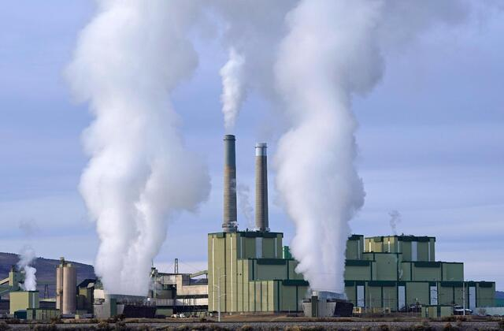

## Overview

- Context: China
  - 24,620 firms
- Methods:
  - RCT of firm assignment to private or public appeals by volunteers monitoring pollution
- Findings:
  - Social media drives public appeals that reduces emissions and violations
  - Public appeals push regulators away from economic growth
  - Reduced emissions by treated firms not offset by emissions from control firms

## Data

### Continuous Emissions Mointoring System (CEMS)

- Hourly emissions data
- 24,620 major polluting plants nationally (75% of total emissions)
- Regulators recieve:
  - Private Appeals: non-observable complaints
  - Public Appeals: observable complaints via social media (Weibo)

## Data

### China 2020

1. Firms
   - 24,620 polluting plants
   - Daily list of verified violations
     - 5,478 polluters
   - Volunteers filing either private or public appeals
     - 12,596 polluting violation appeals
2. Government Response
   - Track local response by officials
   - Weibo messages & replies, 12,369 phone calls, 12,369 website replies

## Empirical Strategy

### Experimental Design

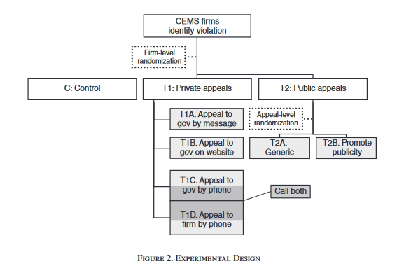

## Empirical Strategy

### Clustered RCT

- $T$: Treatment arm $j$

$$Y_{ijt} = \sum_{j} \alpha_j T_{ij} \times Post_t + \gamma_i + \eta_t + \varepsilon_{ijt}$$

## Results

### Pollution Concentration

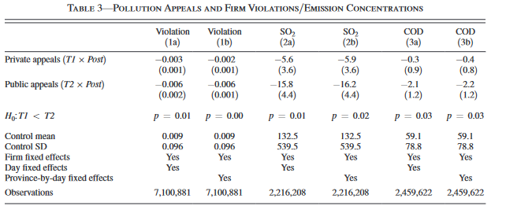

## Results

### Violation Over Time

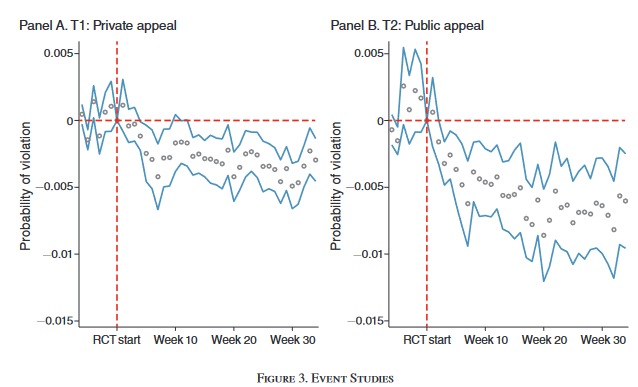

## Results

### Visibility of Appeal

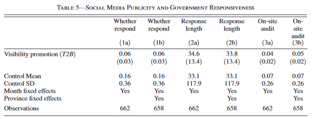

## Results

### General Equilibrium

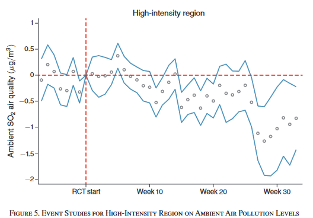